# Self-Driving Car Engineer Nanodegree

## Project: Build a Traffic Sign Recognition Classifier

In this notebook, a template is provided for you to implement your functionality in stages which is required to successfully complete this project. If additional code is required that cannot be included in the notebook, be sure that the Python code is successfully imported and included in your submission, if necessary. Sections that begin with **'Implementation'** in the header indicate where you should begin your implementation for your project. Note that some sections of implementation are optional, and will be marked with **'Optional'** in the header.

In addition to implementing code, there will be questions that you must answer which relate to the project and your implementation. Each section where you will answer a question is preceded by a **'Question'** header. Carefully read each question and provide thorough answers in the following text boxes that begin with **'Answer:'**. Your project submission will be evaluated based on your answers to each of the questions and the implementation you provide.

> **Note:** Code and Markdown cells can be executed using the **Shift + Enter** keyboard shortcut. In addition, Markdown cells can be edited by typically double-clicking the cell to enter edit mode.

## Step 1: Dataset Exploration

Visualize the German Traffic Signs Dataset. This is open ended, some suggestions include: plotting traffic signs images, plotting the count of each sign, etc. Be creative!

The pickled data is a dictionary with 4 key/value pairs:

- features -> the images pixel values, (width, height, channels)
- labels -> the label of the traffic sign
- sizes -> the original width and height of the image, (width, height)
- coords -> coordinates of a bounding box around the sign in the image, (x1, y1, x2, y2). Based the original image (not the resized version).

```python
# Load pickled data
import pickle
import os
import cv2

# TODO: fill this in based on where you saved the training and testing data
training_file = './train.p'
testing_file = './test.p'

with open(training_file, mode='rb') as f:
    train = pickle.load(f)
with open(testing_file, mode='rb') as f:
    test = pickle.load(f)

X_train, y_train = train['features'], train['labels']
X_test, y_test = test['features'], test['labels']
```

```python
X_test.dtype
```

```
dtype('uint8')
```

```python
### To start off let's do a basic data summary.

# TODO: number of training examples
n_train = X_train.shape[0]

# TODO: number of testing examples
n_test = X_test.shape[0]

# TODO: what's the shape of an image?
image_shape = X_test.shape[1:3]

# TODO: how many classes are in the dataset
n_classes = len(list(set(train['labels'])))

print("Number of training examples =", n_train)
print("Number of testing examples =", n_test)
print("Image data shape =", image_shape)
print("Number of classes =", n_classes)
```

```
Number of training examples = 39209
Number of testing examples = 12630
Image data shape = (32, 32)
Number of classes = 43
```

```python
### Data exploration visualization goes here.
### Feel free to use as many code cells as needed.
import matplotlib.pyplot as plt
import matplotlib.image as mpimg
import numpy as np
import cv2
%matplotlib inline
```

```python
if sorted(list(y_train)) == list(y_train):
    print("The training data is sorted")
    print(y_train)
```

```
The training data is sorted
[ 0  0  0 ..., 42 42 42]
```

```python
one_hot_encoded = False
```

```python
y_test[0:20]
```

```
array([16,  1, 38, 33, 11, 38, 18, 12, 25, 35, 12,  7, 23,  7,  4,  9, 21,
       20, 27, 38], dtype=uint8)
```

The test set is not sorted

```python
# check the distribution of the training data over the test set classes
# the training images are grouped by tracks of 30 images, see
#
# http://benchmark.ini.rub.de/?section=gtsrb&subsection=dataset
#
# sanity check that all images come in streams of 30 and count of different tracks per class.
def sanity_check():
    n_seq = 30
    l = list(y_train)
    train_struc=[[x,l.count(x),l.count(x) % n_seq, l.count(x) % n_seq] for x in set(l)]
    faulty_classes = [(faulty_class,rest) for faulty_class,_,rest,_ in train_struc if rest > 0]

    # these are the classes that do not have 30 images in each track
    return faulty_classes

sanity_check()
```

```
[(33, 29)]
```

### Note: *There is a frame missing in class 33. It turns out it is in track 19. This needs to be fixed!*

Plot one representative of each class

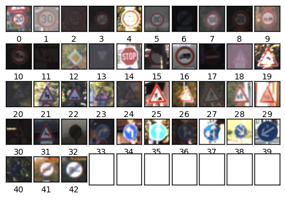

```python
first_indices=[]
for class_num in range(n_classes):
    ind = np.where(y_train==class_num)[0][0]
    first_indices.append(ind)

fig, axes = plt.subplots(5,10)
fig.subplots_adjust(hspace=0.2, wspace=0.1)

for i, ax in enumerate(axes.flat):
    if i<n_classes:
        ax.imshow(X_train[first_indices[i]])
        xlabel = "{0}".format(i)
        ax.set_xlabel(xlabel)
    ax.set_xticks([])
    ax.set_yticks([])


plt.show()
```

```python
# define a plot function
def plot_images(images, n_imgs, cls_true, cls_pred=None):
    assert len(images) == len(cls_true) == n_imgs
    assert not n_imgs % 10

    # Create figure with sub-plots.

    fig, axes = plt.subplots(n_imgs//10,10)
    fig.subplots_adjust(hspace=0.2, wspace=0.1)



    for i, ax in enumerate(axes.flat):
        # Plot image.
        if images.shape[-1]==1:
            ax.imshow(images[i].reshape(image_shape), cmap='gray')
        else:
            ax.imshow(images[i])

        # Show true and predicted classes.
        if cls_pred is None:
            xlabel = "{0}".format(cls_true[i])
        else:
            xlabel = "True: {0}, Pred: {1}".format(cls_true[i], cls_pred[i])

        # Show the classes as the label on the x-axis.
        ax.set_xlabel(xlabel)

        # Remove ticks from the plot.
        ax.set_xticks([])
        ax.set_yticks([])

    # Ensure the plot is shown correctly with multiple plots
    # in a single Notebook cell.
    plt.show()
```

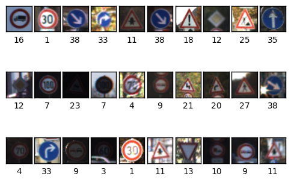

```python
# Get the first images from the test set.
n_imgs =30
images = X_test[0:n_imgs]

# Get the true classes for those images.
cls_true = y_test[0:n_imgs]

# Plot the images and labels using our helper-function above.
plot_images(images=images, n_imgs=n_imgs, cls_true=cls_true)
```

# Conclusions

1. The classes in the data set are not balanced
2. The quality of the images varies greatly. Quite a few raffic signs are not recognizable with the human eye.
3. The lighting conditions vary from bright daylight to darkness, foggy conditions, point of view
4. Some traffic signs are partially obscured.
5. There are not a lot of training examples for all classes
6. *All images are taken from 30 frame video sequences of an approaching camera, except that track 19 of class 33 is missing a frame.*

We will have to deal with the uneven lighting conditions, data augmentation and creation of an appropriate validation set, that does not bleed into the training data. For the latter we take the approach discussed in "Traffic Sign Recognition with Multi-Scale Convolutional Networks", http://yann.lecun.com/exdb/publis/pdf/sermanet-ijcnn-11.pdf

## Step 2: Design and Test a Model Architecture

Design and implement a deep learning model that learns to recognize traffic signs. Train and test your model on the [German Traffic Sign Dataset](http://benchmark.ini.rub.de/?section=gtsrb&subsection=dataset).

There are various aspects to consider when thinking about this problem:

- Your model can be derived from a deep feedforward net or a deep convolutional network.
- Play around preprocessing techniques (normalization, rgb to grayscale, etc)
- Number of examples per label (some have more than others).
- Generate fake data.

Here is an example of a [published baseline model on this problem](http://yann.lecun.com/exdb/publis/pdf/sermanet-ijcnn-11.pdf). It's not required to be familiar with the approach used in the paper but, it's good practice to try to read papers like these.

### Implementation

Use the code cell (or multiple code cells, if necessary) to implement the first step of your project. Once you have completed your implementation and are satisfied with the results, be sure to thoroughly answer the questions that follow.

We begin by defining a few functions needed for preprocessing

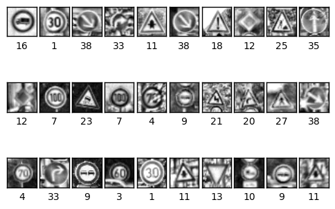

```python
def grayscale(img):
    """Applies the Grayscale transform
    This will return an image with only one color channel
    but NOTE: to see the returned image as grayscale
    you should call plt.imshow(gray, cmap='gray')"""
    shape = img.shape
    img = cv2.cvtColor(img, cv2.COLOR_BGR2GRAY)
    img = img.reshape((shape[0],shape[1],1))
    return img

def applyCLAHE(img):
    """
    Apply local contrast maximization to a single channel uint8 image
    """
    clahe = cv2.createCLAHE(clipLimit=4.0, tileGridSize=(4,4))
    img_clahe = clahe.apply(img)
    return img_clahe

def normalize_grayscale(img):
    """
    Normalize the image data with Min-Max scaling to a range of [0.1, 0.9]
    :param image_data: The image data to be normalized
    :return: Normalized image data
    """
    # ToDo: Implement Min-Max scaling for greyscale image data
    a = 0.1;b = 0.9; Xmin = 0.0;Xmax = 255.0;
    X = img;
    Xp = a + (X-Xmin)*(b-a)/(Xmax-Xmin)
    return Xp

# this function will be used to preprocess all images
def preprocess_images(images):
    shape = images.shape
    out_img_shape=(shape[1],shape[2],1)
    batch = np.zeros((shape[0],shape[1],shape[2],1))

    for i in range(len(images)):
        img = images[i,:]
        img = grayscale(img)
        img = applyCLAHE(img).reshape(out_img_shape)
        img = normalize_grayscale(img)
        batch[i] = img
    return batch

# plot a few to see the result
images = preprocess_images(X_test[0:n_imgs])
plot_images(images=images, n_imgs=n_imgs, cls_true=cls_true)
```

This looks much better. Before we apply the preprocessing function to the whole data set, we augment the data set and then preprocess all images in one go.

```python
# we will do this later
# X_test  = preprocess_images(X_test)
# X_train = preprocess_images(X_train)
```

### Question 1

*Describe the techniques used to preprocess the data.*

**Answer:** As can be seen above many images have very little contrast. Global contrast optimization does not help for images that are very dark or very bright all over. THe data set is not very large and traffic signs are designed to have good contrast. Moreover, working with black and white images provided better results in the benchmark paper "Traffic Sign Recognition with Multi-Scale Convolutional Networks" of the Le Cun group, quoted above. Therefore a preprocessing function was designed that first simply converts all images to grayscale. Subsequently local contrast optimization is applied (CLAHE algorithm), followed by Min-Max normalization which brings the values of all images into the range [0.1, 0.9], as done in the "Finding Lane-Line Project". However, note that a range of [-1:1] would equally have been possible and is actually recommended, see http://www.faqs.org/faqs/ai-faq/neural-nets/part2/. It would be interesting to investigate the effects of different normalization schemes in the future. Particularly, the local contrast optimization greatly helped turning otherwise practically unrecognizable traffic signs into something useful, please compare the sample images above before and after the preprocessing step.

**Note**

1. We will apply the image preprocessing function below after the augmentation of the data set
2. We will also one-hot encode the class labels only after augmentation of the data set.

These two steps are still to come

```python
### Generate data additional (if you want to!)
### and split the data into training/validation/testing sets here.
### Feel free to use as many code cells as needed.

#first duplicate the first frame in class 33 track 19, so all tracks have length 30
class_num = 33
track = 19
first_ind = np.where(y_train==class_num)[0][0]
dup = X_train[first_ind+track*n_seq,:]
X_train = np.insert(X_train,first_ind+track*n_seq, dup, 0)
y_train = np.insert(y_train,first_ind+track*n_seq, 33, 0)

l = list(y_train)
train_struc=[[x,l.count(x),l.count(x) % n_seq, l.count(x)/n_seq] for x in set(l)]

#we perform the sanity check once more
sanity_check()
```

[output not shown]

```python
# We create 2 additional data sets by random translations and rotations of the training set

# set the seed for reproducible results
np.random.seed(seed=40)

def random_translation(img,t_range):
    rows,cols,ch = img.shape
    p=10 #pad the image (reflect the boundary)
    tr_x = t_range*np.random.uniform()-t_range/2
    tr_y = t_range*np.random.uniform()-t_range/2
    Trans_M = np.float32([[1,0,tr_x],[0,1,tr_y]])
    wrap = cv2.copyMakeBorder(img,p,p,p,p,cv2.BORDER_REFLECT)
    img = cv2.warpAffine(wrap,Trans_M,(cols+2*p,rows+2*p))
    img = img[p:p+cols,p:p+rows]
    return img

def random_rotation(img,ang_range):
    rows,cols,ch = img.shape
    p=10 #pad the image (reflect the boundary)
    ang_rot = np.random.uniform(ang_range)-ang_range/2
    Rot_M = cv2.getRotationMatrix2D((cols/2,rows/2),ang_rot,1)
    wrap = cv2.copyMakeBorder(img,p,p,p,p,cv2.BORDER_REFLECT)
    img = cv2.warpAffine(wrap,Rot_M,(cols+2*p,rows+2*p))
    img = img[p:p+cols,p:p+rows]
    return img

X_trans = np.zeros_like(X_train)
X_rot = np.zeros_like(X_train)

for i in range(len(X_train)):
    X_trans[i]=random_translation(X_train[i],t_range=4)
    X_rot[i]=random_rotation(X_train[i],ang_range=30)
```

[figure not shown]

```python
# plot a few of the augmented rotated images
images = X_rot[0:n_imgs]
plot_images(images=images, n_imgs=n_imgs, cls_true=y_train[0:n_imgs])
```

[figure not shown]

```python
# plot a few of the augmented translated images
images = X_trans[0:n_imgs]
plot_images(images=images, n_imgs=n_imgs, cls_true=y_train[0:n_imgs])
```

```python
X_aug = [X_train, X_rot, X_trans]
X_aug = np.vstack(X_aug)
print('Augmented training set',X_aug.shape)
y_aug = [y_train,y_train,y_train]
y_aug = np.hstack(y_aug)
print('Augmented training labels',y_aug.shape)
```

[output not shown]

```python
# validation set creation: pick randomly entire tracks from the training data.
X_train = X_aug
y_train = y_aug

n_train = y_train.shape[0];
n_tracks = int(n_train/n_seq)

tracks = np.arange(n_tracks)
np.random.shuffle(tracks)

val_frac = 0.2 # split 80/20 in training and validation set
n_val_tracks=int(val_frac*n_tracks)
val_tracks   = tracks[:n_val_tracks]
val_tracks   = list(val_tracks)
train_tracks = list(set(tracks)-set(val_tracks))

val_rows=np.array([np.arange(x*n_seq,(x+1)*n_seq) for x in val_tracks])
val_rows=val_rows.flatten()
y_val=y_train[val_rows]
X_val = X_train[val_rows,:]

train_rows=np.array([row for row in np.arange(n_train) if row not in val_rows])
train_rows=train_rows.flatten()
y_train = y_train[train_rows]
X_train = X_train[train_rows,:]

n_train = len(y_train)
n_val   = len(y_val)

# now preprocess all images
X_train = preprocess_images(X_train)
X_val   = preprocess_images(X_val)
X_test  = preprocess_images(X_test)


# sanity check of data
print('classes in training set', len(set(y_train))) # number of classes in new training set
print('classes in validation set',len(set(y_val)))   # number of classes in validation set
print('classes in test set',len(set(y_test)))   # number of classes in test set

print('Training set',X_train.shape, ', y_train',y_train.shape)
print('Validation set',X_val.shape,', y_val ',y_val.shape)
print('Test set',X_test.shape,', y_test ',y_test.shape)
```

[output not shown]

Now shuffle within each set to make sure we're not training on tracks and split off a validation set

```python
from sklearn.utils import shuffle
X_train, y_train = shuffle(X_train, y_train, random_state=0)
X_val, y_val = shuffle(X_val, y_val, random_state=0)
```

```python
y_train_cls=y_train
print(y_train_cls)
y_val_cls=y_val
print(y_val_cls)
y_test_cls=y_test
print(y_test_cls)
type(y_train)
```

```
[ 4 40 17 ...,  9 10  4]
[20 38 33 ..., 29 29  8]
[16  1 38 ...,  6  7 10]
```

```
numpy.ndarray
```

one hot encode the labels:

```python
# Turn labels into numbers and apply One-Hot Encoding
from sklearn.preprocessing import LabelBinarizer
encoder = LabelBinarizer()
encoder.fit(y_train)
y_train = encoder.transform(y_train)
y_val   = encoder.transform(y_val)
y_test   = encoder.transform(y_test)

# Change to float32, so it can be multiplied against the features in TensorFlow, which are float32
y_train = y_train.astype(np.float32)
y_val = y_val.astype(np.float32)
y_test = y_test.astype(np.float32)
is_labels_encod = True

print('Labels One-Hot Encoded')
```

```
Labels One-Hot Encoded
```

```python
X_train = X_train.astype(np.float32)
X_val   = X_val.astype(np.float32)
X_test  = X_test.astype(np.float32)
```

```python
# Save the data for easy access
pickle_file = 'preprocessed_data.p'
if not os.path.isfile(pickle_file):
    print('Saving data to pickle file...')
    try:
        with open(pickle_file, 'wb') as pfile:
            pickle.dump(
                {
                    'X_train': X_train,
                    'y_train': y_train,
                    'y_train_cls': y_train_cls,
                    'X_val': X_val,
                    'y_val': y_val,
                    'y_val_cls': y_val_cls,
                    'X_test': X_test,
                    'y_test': y_test,
                    'y_test_cls': y_test_cls
                },
                pfile, pickle.HIGHEST_PROTOCOL)
    except Exception as e:
        print('Unable to save data to', pickle_file, ':', e)
        raise

print('Data cached in pickle file.')
```

```
Data cached in pickle file.
```

### Question 2

*Describe how you set up the training, validation and testing data for your model. If you generated additional data, why?*

**Answer:** Since the training data comes in tracks of 30, it is crucial to not just randomize all the training images and split into training and validation set. The rationale for doing so is that images of the same track are obviously very similar. Initial random shuffling is therefore akin to including training examples in the validation set. While I have not explicitly verified it myself here, it was reported that such a general randomization leads to poor test results http://yann.lecun.com/exdb/publis/pdf/sermanet-ijcnn-11.pdf

We therefore completed the one track that was missing an image by duplicating the first image of the respective track. We then created one additional training sets by applying random shifts to all images of the original training data. The same procedure was carried out by applying random rotations to all original training images. In the first augmentation data set the images where shifted uniformly randomly in the x and y direction by +-2 pixels. In the second augmentation data set random rotations of +-15 degrees were applied. To avoid introducing further artefacts arising from these transformations a reflective boundary condition was used which prevents strong contrast variations at the boundary. Thus we obtained an augmented data set which is 3x the size of the original training data.

This approach does **not** balance the classes. It assumes that test and training images are samples of the same population and balancing the classes might skew the results more than helping, but this hypothesis has not been tested. This approach was also used in the baseline paper. It might introduce a bias, but not all traffic signs occur in reality at the same frequency and it might be OK to not balance the classes here. It would be interesting to repeat these computations with an augmented data set with balanced classes, but time constraints do not allow for this.

The augmented data set was then split into training and validation **tracks** at a ratio of 80/20. So entire tracks were kept together, to avoid the aforementioned bleeding of training data into the validation set. After this split was performed all training and validation data was individually shuffled to avoid training the model on entire tracks.

Finally we changed the type of all variables to np.float32 (not doing so, is a performance killer, as I found out the hard way), one-hot encoded the labels and saved the new augmented data set for later in a pickle file.

# Checkpoint

We can load the data from here. Only the plot_images function needs to be additionally loaded.

```python
%matplotlib inline
import pickle
import matplotlib.pyplot as plt
import matplotlib.image as mpimg
import tensorflow as tf
import numpy as np
import time
from datetime import timedelta
import math
from tqdm import tqdm
# Reload the data

restart=True
pickle_file = 'preprocessed_data.p'
if restart:
    with open(pickle_file, 'rb') as f:
        pickle_data = pickle.load(f)
        X_train = pickle_data['X_train']
        y_train = pickle_data['y_train']
        y_train_cls = pickle_data['y_train_cls']
        X_val = pickle_data['X_val']
        y_val = pickle_data['y_val']
        y_val_cls = pickle_data['y_val_cls']
        X_test = pickle_data['X_test']
        y_test = pickle_data['y_test']
        y_test_cls = pickle_data['y_test_cls']
        del pickle_data  # Free up memory


print('Data and modules loaded.')

n_train = X_train.shape[0]
n_val   = X_val.shape[0]
n_test =  X_test.shape[0]
image_shape = X_test.shape[1:3]
n_classes = y_train.shape[1]



print("Number of training examples =", n_train)
print("Number of validation examples =", n_val)
print("Number of testing examples =", n_test)
print("Image data shape =", image_shape)
print("Number of classes =", n_classes)
print("X_train data type =", X_train.dtype)
print("X_val data type =", X_val.dtype)
print("X_test data type =", X_test.dtype)
print("y_train data type =", y_train.dtype)
print("y_val data type =", y_val.dtype)
print("y_test data type =", y_test.dtype)
```

```
Data and modules loaded.
Number of training examples = 94110
Number of validation examples = 23520
Number of testing examples = 12630
Image data shape = (32, 32)
Number of classes = 43
X_train data type = float32
X_val data type = float32
X_test data type = float32
y_train data type = float32
y_val data type = float32
y_test data type = float32
```

```python
### Define your architecture here.
### Feel free to use as many code cells as needed.
#   We build on the 2 layer CNN model architecture with max pooling provided at
#   http://github.com/Hvass_Labs


# Convolutional Layer 1.
filter_size1 = 5          # Convolution filters are 5 x 5 pixels.
num_filters1 = 16         # There are 16 of these filters.

# Convolutional Layer 2.
filter_size2 = 5          # Convolution filters are 5 x 5 pixels.
num_filters2 = 36         # There are 36 of these filters.

# Fully-connected layer.
fc_size = 128             # Number of neurons in fully-connected layer.

# We know that the images are 32 pixels in each dimension.
img_size = 32

# Images are stored in one-dimensional arrays of this length.
img_size_flat = img_size * img_size

# Tuple with height and width of images used to reshape arrays.
img_shape = (img_size, img_size)

# Number of colour channels for the images: 1 channel for gray-scale.
num_channels = 1

# Number of classes, one class for each of 10 digits.
num_classes = n_classes

# only used sometimes for plotting
n_imgs = 10
```

# Model building stage

Define a few helper functions for building the model.

```python
def new_weights(shape):
    return tf.Variable(tf.truncated_normal(shape, stddev=0.05))

def new_biases(length):
    return tf.Variable(tf.constant(0.05, shape=[length]))

def new_conv_layer(input,              # The previous layer.
                   num_input_channels, # Num. channels in prev. layer.
                   filter_size,        # Width and height of each filter.
                   num_filters,        # Number of filters.
                   use_pooling=True):  # Use 2x2 max-pooling.

    shape = [filter_size, filter_size, num_input_channels, num_filters]

    # Create new weights aka. filters with the given shape.
    weights = new_weights(shape=shape)

    # Create new biases, one for each filter.
    biases = new_biases(length=num_filters)

    layer = tf.nn.conv2d(input=input,
                         filter=weights,
                         strides=[1, 1, 1, 1],
                         padding='SAME')

    # Add the biases to the results of the convolution.
    # A bias-value is added to each filter-channel.
    layer += biases

    layer = tf.nn.max_pool(value=layer,
                           ksize=[1, 2, 2, 1],
                           strides=[1, 2, 2, 1],
                           padding='SAME')

    layer = tf.nn.relu(layer)

    return layer, weights

def flatten_layer(layer):
    # Get the shape of the input layer.
    layer_shape = layer.get_shape()
    # The shape of the input layer is assumed to be:
    # layer_shape == [num_images, img_height, img_width, num_channels]

    # The number of features is: img_height * img_width * num_channels
    num_features = layer_shape[1:4].num_elements()

    # Reshape the layer to [num_images, num_features].
    layer_flat = tf.reshape(layer, [-1, num_features])

    return layer_flat, num_features

def new_fc_layer(input,          # The previous layer.
                 num_inputs,     # Num. inputs from prev. layer.
                 num_outputs,    # Num. outputs.
                 use_relu=True): # Use Rectified Linear Unit (ReLU)?

    # Create new weights and biases.
    weights = new_weights(shape=[num_inputs, num_outputs])
    biases = new_biases(length=num_outputs)

    # Calculate the layer as the matrix multiplication of
    # the input and weights, and then add the bias-values.
    layer = tf.matmul(input, weights) + biases

    # Use ReLU?
    if use_relu:
        layer = tf.nn.relu(layer)

    return layer
```

# Build a 2-layer CNN with max-pooling and 2 fully connected layers with dropout regularization

```python
tf.reset_default_graph() # important for reloading

x_image = tf.placeholder(tf.float32, shape=[None,img_size, img_size, num_channels], name='x')
y_true = tf.placeholder(tf.float32, shape=[None, n_classes], name='y_true')
y_true_cls = tf.argmax(y_true, dimension=1)
```

```python
layer_conv1, weights_conv1 = \
    new_conv_layer(input=x_image,
                   num_input_channels=num_channels,
                   filter_size=filter_size1,
                   num_filters=num_filters1,
                   use_pooling=True)
layer_conv1
```

```
<tf.Tensor 'Relu:0' shape=(?, 16, 16, 16) dtype=float32>
```

```python
layer_conv2, weights_conv2 = \
    new_conv_layer(input=layer_conv1,
                   num_input_channels=num_filters1,
                   filter_size=filter_size2,
                   num_filters=num_filters2,
                   use_pooling=True)
layer_conv2
```

```
<tf.Tensor 'Relu_1:0' shape=(?, 8, 8, 36) dtype=float32>
```

```python
layer_flat, num_features = flatten_layer(layer_conv2)
layer_flat
```

```
<tf.Tensor 'Reshape:0' shape=(?, 2304) dtype=float32>
```

```python
keep_prob = tf.placeholder(tf.float32)
dropout_layer = tf.nn.dropout(layer_flat, keep_prob)
```

```python
layer_fc1 = new_fc_layer(input=dropout_layer,
                         num_inputs=num_features,
                         num_outputs=fc_size,
                         use_relu=True)
layer_fc1
```

```
<tf.Tensor 'Relu_2:0' shape=(?, 128) dtype=float32>
```

```python
layer_fc2 = new_fc_layer(input=layer_fc1,
                         num_inputs=fc_size,
                         num_outputs=num_classes,
                         use_relu=False)
layer_fc2
```

```
<tf.Tensor 'add_3:0' shape=(?, 43) dtype=float32>
```

```python
y_pred = tf.nn.softmax(layer_fc2)
y_pred_cls = tf.argmax(y_pred, dimension=1)
y_pred
y_pred_cls
```

```
<tf.Tensor 'ArgMax_1:0' shape=(?,) dtype=int64>
```

```python
cross_entropy = tf.nn.softmax_cross_entropy_with_logits(logits=layer_fc2,labels=y_true)
loss = tf.reduce_mean(cross_entropy)
optimizer = tf.train.AdamOptimizer(learning_rate=1e-4).minimize(loss)

correct_prediction = tf.equal(y_pred_cls, y_true_cls)
accuracy = tf.reduce_mean(tf.cast(correct_prediction, tf.float32))
init = tf.initialize_all_variables()
saver = tf.train.Saver()

# Feed dicts for training, validation, and test session
valid_feed_dict = {x_image: X_val, y_true: y_val,keep_prob: 1.0}
test_feed_dict  = {x_image: X_test, y_true: y_test,keep_prob: 1.0}
```

### Question 3

*What does your final architecture look like? (Type of model, layers, sizes, connectivity, etc.) For reference on how to build a deep neural network using TensorFlow, see Deep Neural Network in TensorFlow from the classroom.*

**Answer:** The final architecture is a model consisting of two convolutional layers with ReLUs inside it. I started from https://github.com/Hvass-Labs/TensorFlow-Tutorials/blob/master/02_Convolutional_Neural_Network.ipynb Originally the intent was to stick closely to the baseline paper of the Le Cun group, and also to introduce layer skipping, i.e. feeding the output of the first convolutional layer to the first fully connected layer. However, this proved timewise challenging and I decided to modify the architecture of the model there only to match the traffic sign competition and by including a dropout layer.

Each convolutional layer is followed by 2x2 max pooling. The depths of the convolutional layers are 16 for the first and 36 for the second respectively. Accordingly, with SAME padding the first convolutional layer has a size of 16x16x16, the second one 8x8x36=2304, the first fully connected layer has 128 hidden units and works as a dropout layer, the second fully connected one is the output layer with 43 units. ReLUs are used in all but the output layer which is just a linear layer of which the cross-entropy gets calculated.